# Visualising Tennis Serves

26 September 2016

## The Goal

## Realistic Summaries

- Summaries of serve trajectories that can be interpreted by TV audiences
- Summaries that can be utilised by researches for visualising serve data

## Key Characteristics

- Position (\(t\), \(x\), \(y\) ,\(z\))
- Speed (\(v_{initial}\), changes in \(v\) due to the surface)
- Spin (side spin, top spin)
- Strategy (single serves, serve clusters)

## Background

## Current Methods

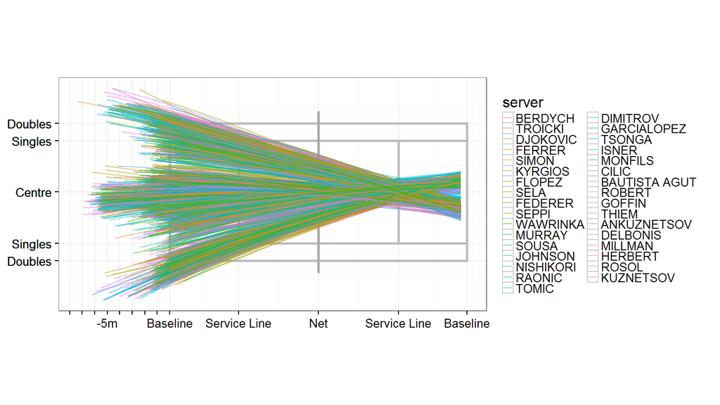

All serve paths as overlayed lines

## Current Methods

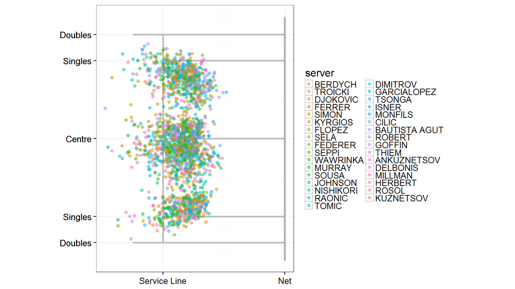

Landing positions of all serves

## Current Methods

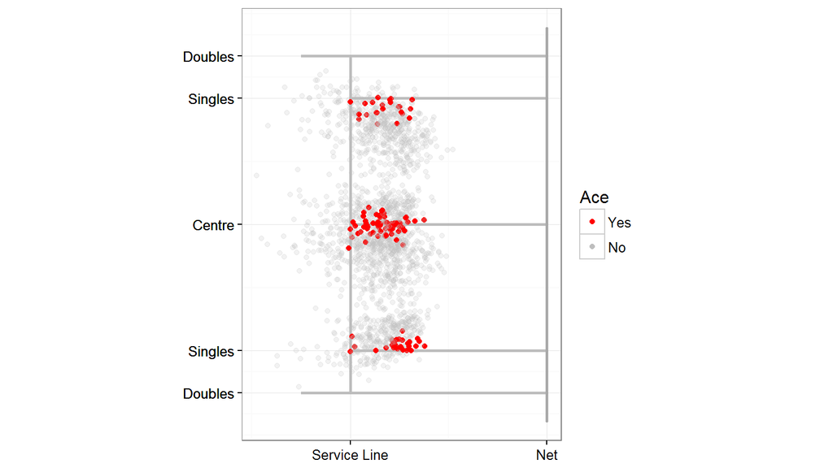

Landing positions of aces

## Visualising Higher Dimensional Data

### Bad Method

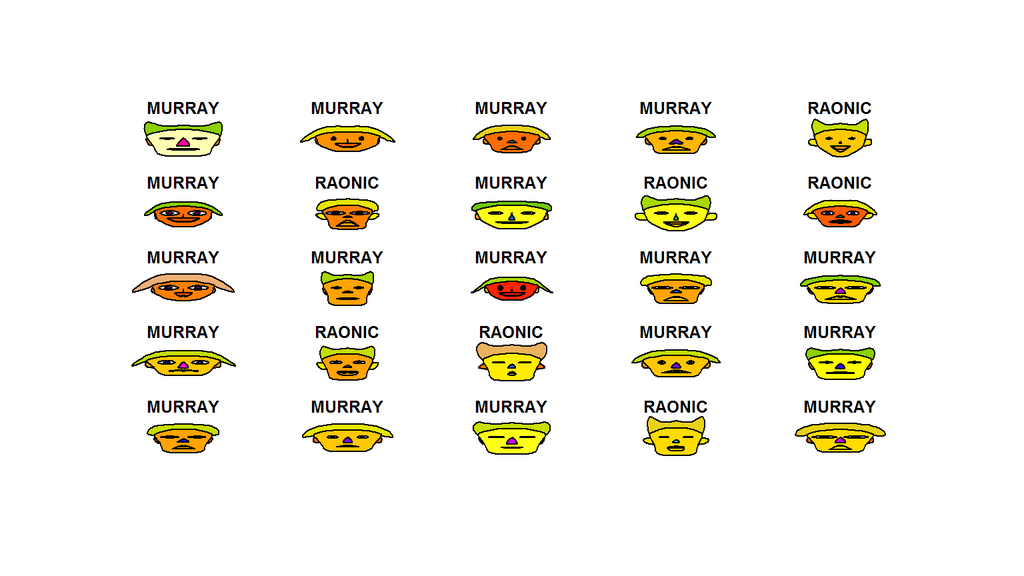

Chernoff faces

## Visualising Higher Dimensional Data

### Less Bad Method

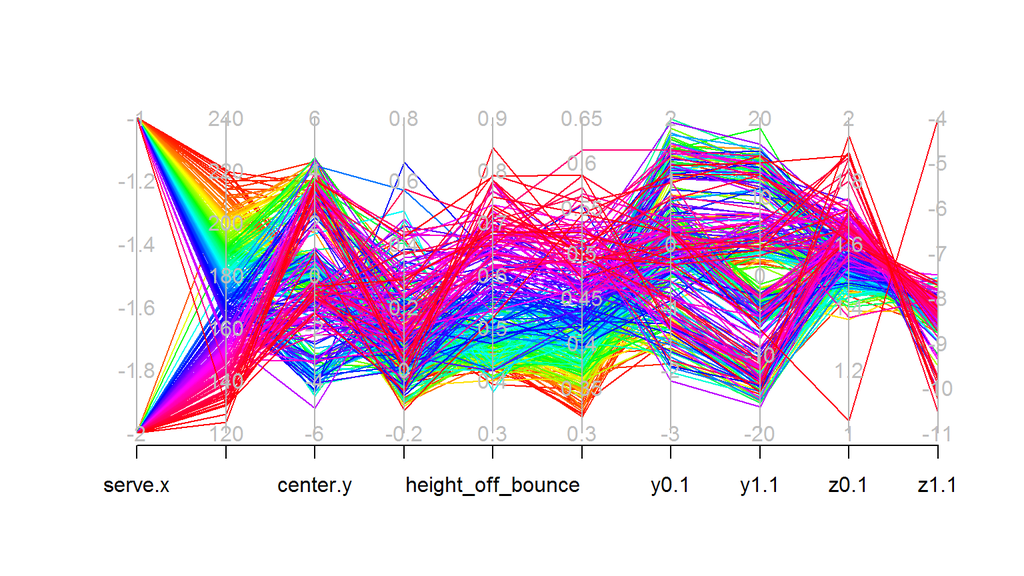

Parallel Coordinates

## Shape

## Hexagonal Binnning

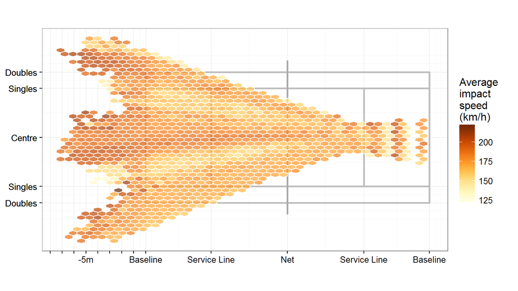

Average impact speed in hexagonal bins

## Hexagonal Binnning

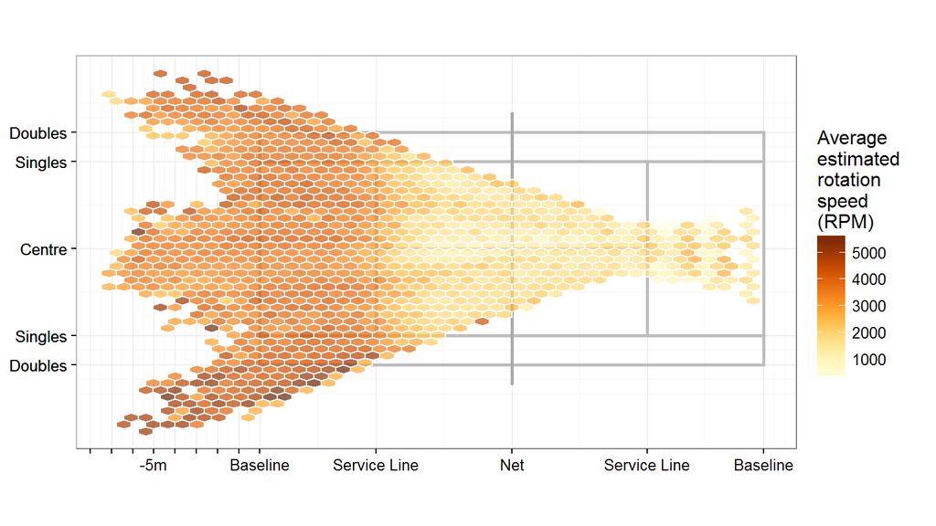

Average estimated rotational speed in hexagonal bins

## Hexagonal Binnning

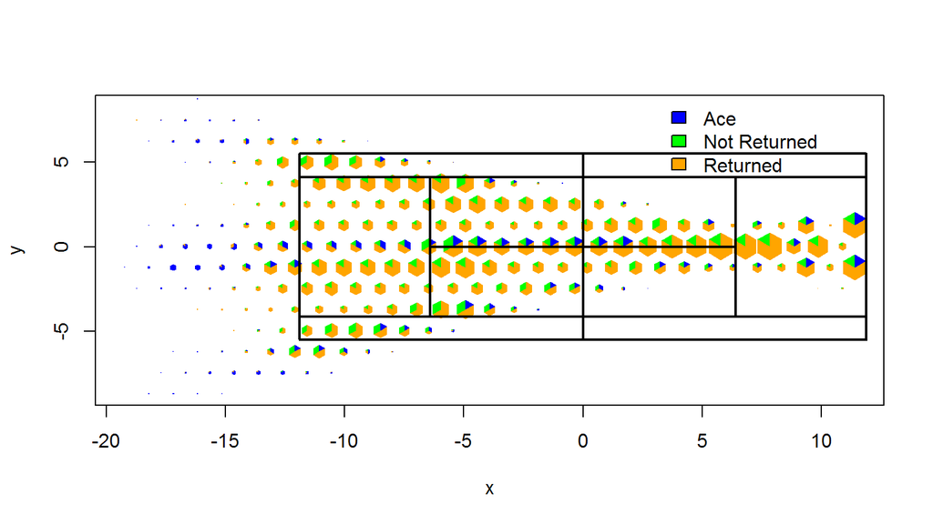

Serve type using Hextri

## Interpretation

Is it even necessary to show the entire path?

## Split Path with Landing Positions

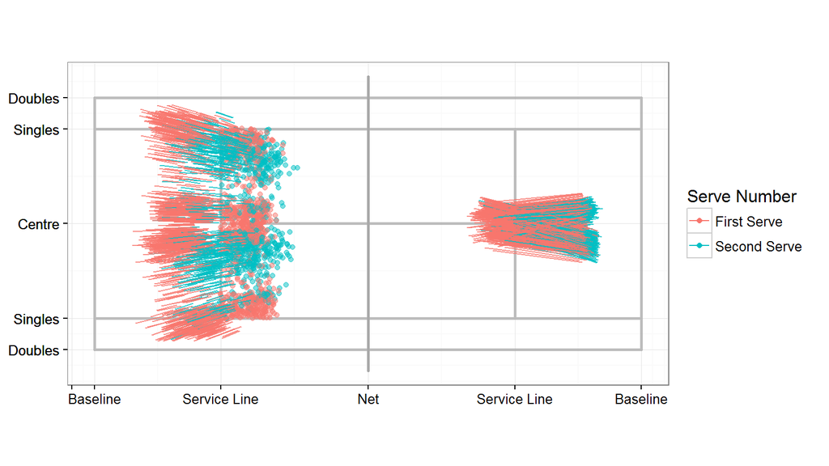

Split landing position coloured by serve number

## Murray and Raonic

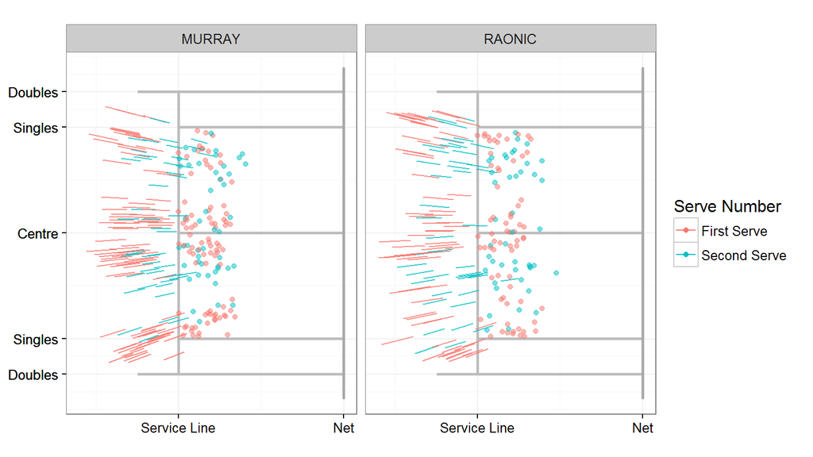

Split landing position coloured by serve number

## Comparison of Contour Plots

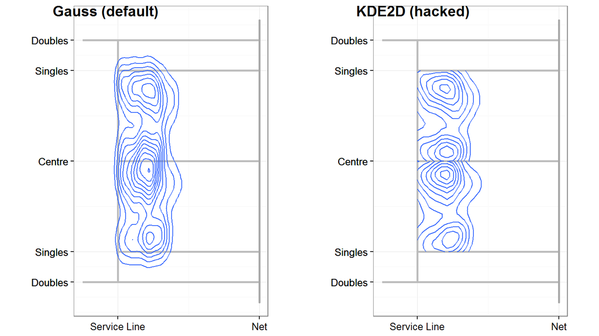

Effect of limits on contour plots

## Comparison of Different Players

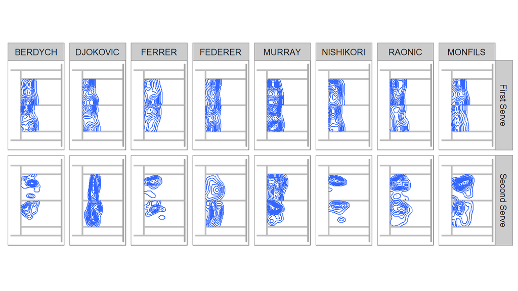

Players who've played at least 3 games

## Comparison of Top and Bottom Players

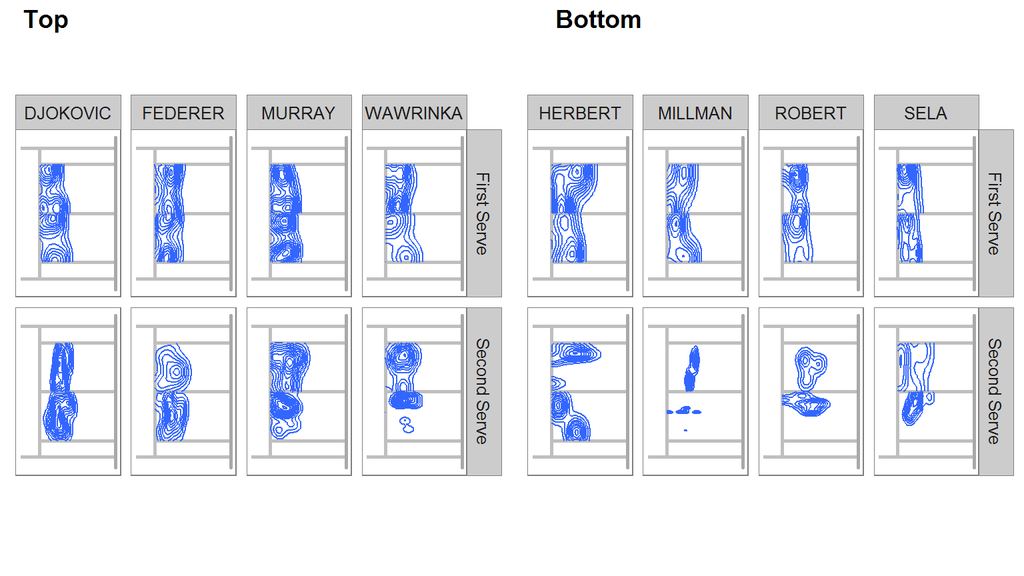

Comparison of top ranked (1, 2, 3, 4) and bottom ranked (87, 95, 167, 225) in the sample

## Speed

## Speed and Landing Position

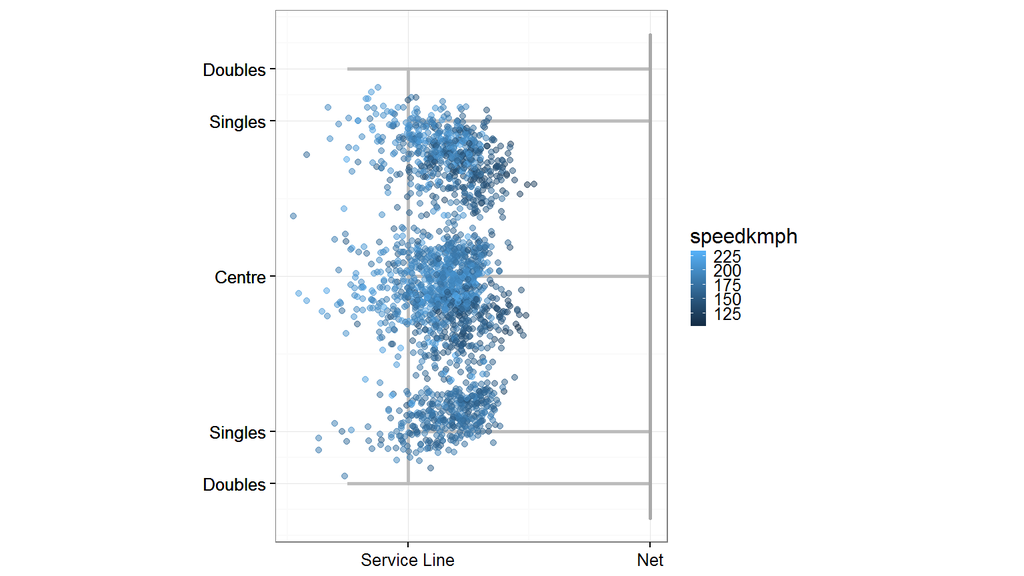

Landing positions of all serves coloured by speed

## Speed and Importance

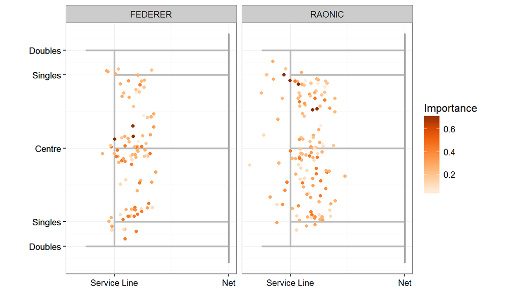

## Novak

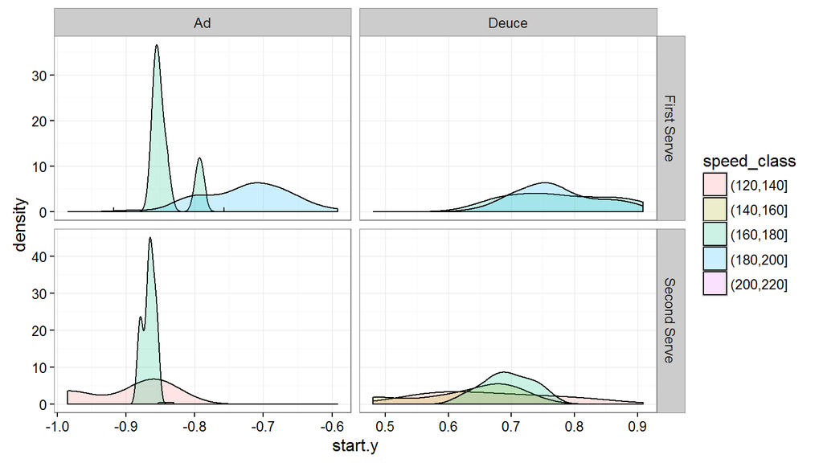

## Kyrgios

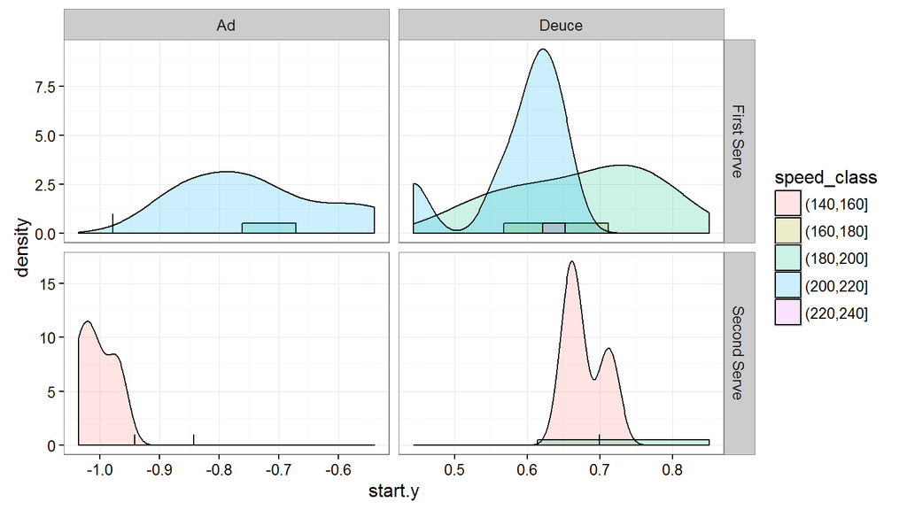

## Spin

## Importance of Spin

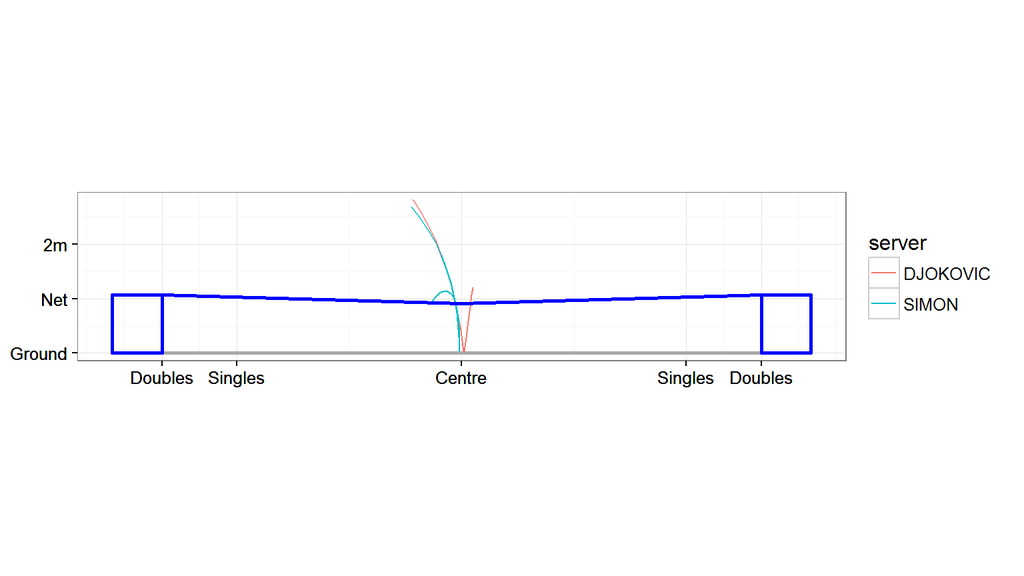

Importance of spin

## Spin Model

### Just a simple matter of…

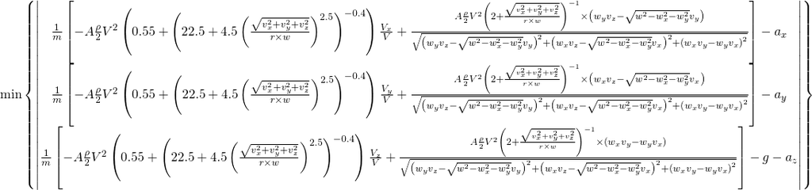

## Spin Model Overview

\[\text{Prediction:}\qquad\vec{a}_{\text{p}}=\frac{\vec{F}_{\text{net}}}{m}=\frac{\vec{L}}{m}+\frac{\vec{D}}{m}+\vec{g} \\ \text{Lift Force:}\qquad\vec{L}=\left|L\right|\cdot\frac{\vec{W}\times\vec{V}}{\left|\vec{W}\times\vec{V}\right|}\qquad\left|L\right|=A\frac{\rho}{2}V^{2}\left(\frac{1}{2+\frac{V}{V_{s}}}\right) \\ \text{Drag Force:}\qquad\vec{D}=-\left|D\right|\cdot\frac{\vec{V}}{\left|V\right|}\quad\left|D\right|=A\frac{\rho}{2}V^{2}\left(0.55+\frac{1}{\left(22.5+4.5\left(\frac{V}{V_{S}}\right)^{2.5}\right)^{0.4}}\right)\]

## Spin Model Overview

\[\vec{W}=w_{x}\vec{i}+w_{y}\vec{j}+\sqrt{w^{2}-w_{x}^{2}-w_{y}^{2}}\,\vec{k} \\ \text{from} \\ \vec{a}=a_{x}\vec{i}+a_{y}\vec{j}+a_{z}\vec{k} \quad \text{and} \quad \vec{v}=a_{x}\vec{i}+v_{y}\vec{j}+v_{z}\vec{k}\]

## Spin vs Speed

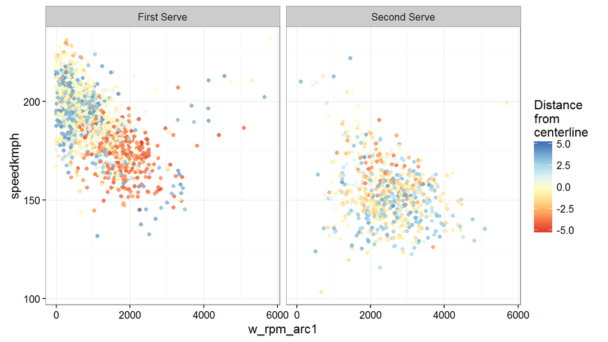

## Speed and Spin of Top Players

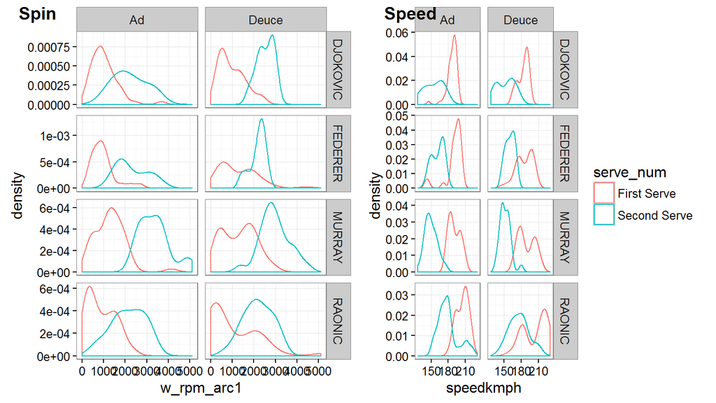

## Federer and Raonic

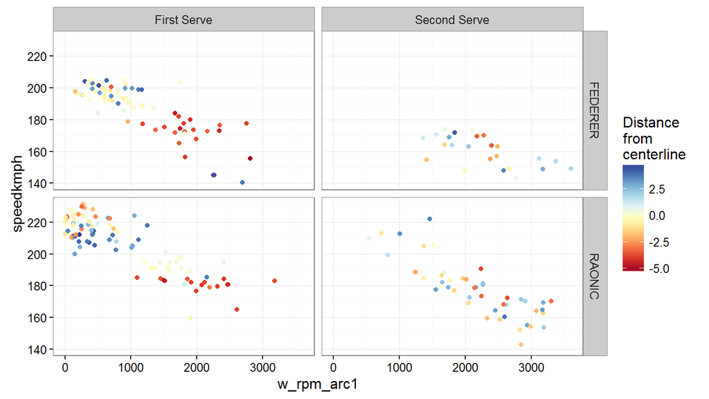